# Ayudantía 3 - Regresión Lineal …

Diego Bernal Soto: diego.bernals@usm.cl

# Definiciones

1. **Suma Cadrada total (SST)**: Estadistico que da cuenta de la variabilidad de un conjunto de *n* mediciones agrupaddas en *i-grupos*, con *j* elementos cada uno. Cabe señalar que j es constante para todos los gruposa analizar. Matematicamente se escribe asi.

$${\sum_{i=1}^{n} (y_i - \bar{
y})^2}$$

Como es una suma general del conjunto, esta se puede descomponer en 2 analisis distintos. Entre losgrupos y dentro de ellos.

2. **Suma inter grupos (SSW)**: Este estadastico que representa la variabilidad interna de cada grupo, cuanto se dispersa cada observacion individual respecto al promedio del grupo. ¿Que pasa si este valor es pequeño?.

$${\sum_{i=1}^{I}\sum_{j=1}^{J}(Y_{ij}- \bar{Y_i})^2}$$
3. **Suma entre grupos (SSB)**: Estadistico mide la variabilidad entre grupos, que tanto cambian los promedios de cada grupo con respecto al promedio general.¿Que ocurre si el valor es alto?.

$${\sum_{i=1}^{I}\sum_{j=1}^{J}(Y_{i}- \bar{Y})^2}$$

4. **Error cuadratico medio (MSE)** : Función que nospermite cuantificar que tan bien se ajusta nuestro modelo a la f(x) en relación a los valores predichos.

$$J(w) = \frac{1}{2} \| Xw - Y \|^2$$

# Matematico

Show that the sum of squares decomposition and F-statistic reduces to the equal-variance (pooled) two samples t-test in the case of $\alpha = 2$ treatments with the realization that an F-statistic with 1 numerator and k denominators. degrees of freedom is equivalent to a t-statistic with 1 numerator and k degrees of freedom, viz

$$F_{1, k} = t_{k}^2$$

$$F_{\alpha-1, N - \alpha} = \frac{MST}{MSE} = \frac{\frac{SST}{\alpha-1}}{\frac{SSE}{N-\alpha}}$$

Reduces

$$t_k^2 = \frac{(\bar{y}_1 - \bar{y}_2)^2}{S_p^2 \left( \frac{1}{n_1} + \frac{1}{n_2} \right)}
\quad ; \quad
t_k = \frac{\bar{y}_1 - \bar{y}_2}{S_p \sqrt{ \frac{1}{n_1} + \frac{1}{n_2} }}$$

Cuando $\alpha = 2$

$$MSE = \frac{SSE}{N-2} = \frac{\sum_{j=1}^{n_1}(y_{1j}-\bar{y_1})^2+\sum_{j=1}^{n_1}(y_{2j}-\bar{y_2})^2}
{N-2}$$

Recordando q la formula de la varianza de la muestra estimada es:

$$S_{i}^2 = \frac{\sum_{j=1}^{n_i}(y_{ij}-\bar{y_i})^2}{n_i-1}$$

$$\frac{\sum_{j=1}^{n_1}(y_{1j}-\bar{y_1})^2+\sum_{j=1}^{n_1}(y_{2j}-\bar{y_2})^2}
{N-2} \space * \frac{n_i-1}{n_i-1}$$

$$\frac{\sum_{j=1}^{n_1}(y_{1j}-\bar{y_1})^2 *(n_i-1)+\sum_{j=1}^{n_2}(y_{2j}-\bar{y_2})^2*(n_i-1)}
{(n_1+n_2-2)*(n_i-1)}$$

$$\frac{SSE}{N-2} = \frac{(n_1-1)S_{1}^2+ (n_2 -1)S_{2}^2}{n_1+n_2-2} = S_p$$

$$\frac{SST}{2-1} = SST \to \sum\_{1}^{2}n_i(^\bar{y_i}-\bar{y})2 \space = n_1(\bar{y_1}-\bar{y})^2 + n_2(\bar{y_2}-\bar{y})^2$$

$$y_t \to global\space mean$$

$$\bar{y} = \frac{n_1\bar{y_1}+n_2\bar{y_2}}{N}$$

$$SST = n_1(\bar{y_1} - (\frac{n_1\bar{y_1} + n_2\bar{y_2}}{N}))^2 +
n_2(\bar{y_2} - (\frac{n_1\bar{y_1} + n_2\bar{y_2}}{N}))^2$$

Trabajemos con la primera

$$n_1(\bar{y_1} - (\frac{n_1\bar{y_1} + n_2\bar{y_2}}{N}))^2$$

$$n_1(\frac{N\bar{y_1}}{N} - (\frac{n_1\bar{y_1} + n_2\bar{y_2}}{N}))^2$$

$$n_1(\frac{N\bar{y_1} - n_1\bar{y_1}-n_2\bar{y_2}}{N})^2$$

$$n_1(\frac{(n_1+n_2)\bar{y_1} - n_1\bar{y_1}-n_2\bar{y_2}}{N})^2$$

Recuciendo

$$n_1(\frac{n_2\bar{y_1} + n_2\bar{y_2}}{N})^2$$

$$\frac{n_1n_{2}^2(\bar{y_1}+\bar{y_2})^2}{N^2}$$

El otro termino se deja para que el estudiante suelte la mano…

$$SST = \frac{n_1n_{2}^2(\bar{y_1}+\bar{y_2})^2}{N^2} + \frac{n_2n_{1}^2(\bar{y_1}+\bar{y_2})^2}{N^2}$$

$$\frac{n_1n_{2}^2}{N^2} + \frac{n_2n_{1}^2}{N^2} \to \frac{(n_1+n_2)n_1n_2}{N^2}$$

$$\frac{n_1n_2}{N} \to \frac{1}{\frac{N}{n_1n_2}} \to \frac{1}{\frac{1}{n_1} + \frac{1}{n_2}}$$

$$SST = \frac{1}{\frac{1}{n_1} + \frac{1}{n_2}} * (\bar{y_1} - \bar{y_2})^2$$

Reemplazamos SST y SSE;

$$\frac{\frac{SST}{2-1}}{\frac{SSE}{N-2}} = \frac{\frac{(\bar{y_1}-\bar{y_2})^2}{\frac{1}{n_1} + \frac{1}{n_2}}}
{S_{p}^2} = \frac{(\bar{y_1}-\bar{y_2})^2}{(S_{p}^2(\frac{1}{n_1} + \frac{1}{n_2}))}$$

$$\therefore F_{(1,k)} = t_{k}^2$$

# Formulas que nos ayudan con el enunciado 2 y 1:

$$S{Y|X}^2 = \frac{SCE}{n-2} = (Residual \space standard \space error){2}$$

$$S_{Y}^2 =\frac{n}{n-1}(\bar{Y}^2-(\bar{Y})^2)$$

$$R^2 = 1- \frac{SCE}{SCT} = 1- \frac{(n-1)}{(n-2)}\frac{S_{Y|X}^2}{S_{Y}^2}$$

$$T_{\hat{\alpha}} = \frac{\hat{\alpha}}{\sqrt{\hat{VAR(\hat\alpha)}}}$$

$$T_{\hat\beta} = \frac{\hat{\beta}}{\sqrt{\hat{VAR(\hat\beta)}}}$$

$$F = T_{\hat\beta}^2 = \frac{\frac{SCR}{1}}{\frac{SCE}{(n-2)}}$$

$$SCT = SCR + SCE = n*(\bar{Y}^2 - (\bar{Y})^2)$$

# Enunciado I

1. Significa que un $6.4%$ de la variabilidad del coeficiente de gini es expplicada por el gasto de educación.
2. Prueba de significancia global del modelo

$$H_0; \beta_i = o, \forall e \in 1 \dots k$$
$$H_a; \beta_i \neq 0$$

$$F = \frac{\frac{SSR}{k}}{\frac{SSE}{N-k-1}} ~ F_{(k,n-k-1,\alpha)}$$

Significa que al menos una de las variables del modelo es significativa para explicar la variable dependiente.

3. Prueba de significancia individual

$$H_0; \beta_k = 0$$

$$H_a; \beta_k \neq 0$$

$$T = \frac{\hat{\beta_k}}{SE(\hat\beta_k)} ~ t_{student, (n-k-1)}$$

$|t| > t_{crit} \to$ Rechazamos $H_0$ y concluimos que la variable k si aporta información (significativa) para predecirla variable dependiente.

4. Grafico

```r
#install.packages("tydiverse")
#install.packages("stargazer")
library(tidyverse)
library(remotes)
library(stargazer)#Tablas
library(tidyverse) #meta-package
library(readxl) #Leer hojas de excel
```

```r
remotes::install_github("arcruz0/paqueteadp")
library(paqueteadp)#datos
data("bienestar")
summary(bienestar)
```

[output not shown]

```r
glimpse(bienestar)
```

```
## Rows: 1,074
## Columns: 15
## $ pais                 <chr> "Argentina", "Argentina", "Argentina", "Argentina…
## $ codigo_pais          <chr> "ARG", "ARG", "ARG", "ARG", "ARG", "ARG", "ARG", …
## $ anio                 <dbl> 1970, 1971, 1972, 1973, 1974, 1975, 1976, 1977, 1…
## $ poblacion            <dbl> 29.34501, 29.22258, 29.12433, 29.07185, 29.09083,…
## $ gini                 <dbl> 36.1, NA, 35.3, NA, 32.0, 36.1, 35.2, 40.3, 43.4,…
## $ dualismo_sectorial   <dbl> NA, NA, NA, NA, NA, NA, NA, NA, NA, NA, NA, NA, 9…
## $ pib                  <dbl> 7809.74, 7968.57, 7955.78, 8025.39, 8364.00, 8164…
## $ inversion_extranjera <dbl> 0.28422430, 0.37746448, 0.20648950, 0.19079248, 0…
## $ diversidad_etnica    <dbl> 0, 0, 0, 0, 0, 0, 0, 0, 0, 0, 0, 0, 0, 0, 0, 0, 0…
## $ tipo_regimen         <dbl> 2, 2, 2, 2, 3, 3, 2, 2, 2, 2, 2, 2, 2, 2, 4, 4, 4…
## $ gasto_educ           <dbl> 1.0, 0.6, 1.2, 1.6, 1.4, 1.8, 0.8, 1.4, 1.6, 1.4,…
## $ gasto_salud          <dbl> 0.3, 0.4, 0.4, 0.5, 0.3, 0.4, 0.4, 0.8, 0.6, 0.4,…
## $ gasto_segsocial      <dbl> 5.0, 4.6, 3.9, 4.6, 5.4, 4.7, 3.6, 3.7, 5.2, 7.0,…
## $ bal_legislativo      <dbl> 0.00000000, 0.00000000, 0.00000000, -0.04938280, …
## $ represion            <dbl> 1.0, 1.0, 1.0, 0.5, 0.0, 0.0, 1.0, 1.0, 1.0, 1.0,…
```

```r
reg_1 <- lm(gini~gasto_educ,data = bienestar)
summary(reg_1)
```

```
##
## Call:
## lm(formula = gini ~ gasto_educ, data = bienestar)
##
## Residuals:
##     Min      1Q  Median      3Q     Max
## -20.036  -5.616   1.086   4.990  15.571
##
## Coefficients:
##             Estimate Std. Error t value Pr(>|t|)
## (Intercept)  44.8052     1.0230  43.798  < 2e-16 ***
## gasto_educ    1.2326     0.2502   4.927 1.29e-06 ***
## ---
## Signif. codes:  0 '***' 0.001 '**' 0.01 '*' 0.05 '.' 0.1 ' ' 1
##
## Residual standard error: 6.703 on 354 degrees of freedom
##   (718 observations deleted due to missingness)
## Multiple R-squared:  0.06417,    Adjusted R-squared:  0.06152
## F-statistic: 24.27 on 1 and 354 DF,  p-value: 1.286e-06
```

```r
library(stargazer)
stargazer(reg_1, type = "html")
```

|  | *Dependent variable:* |
| --- | --- |
|  | gini |
| gasto_educ | 1.233*** |
|  | (0.250) |
| Constant | 44.805*** |
|  | (1.023) |
| Observations | 356 |
| R<sup>2</sup> | 0.064 |
| Adjusted R<sup>2</sup> | 0.062 |
| Residual Std. Error | 6.703 (df = 354) |
| F Statistic | 24.272*** (df = 1; 354) |
| *Note:* | p<0.1; p<0.05; p<0.01 |

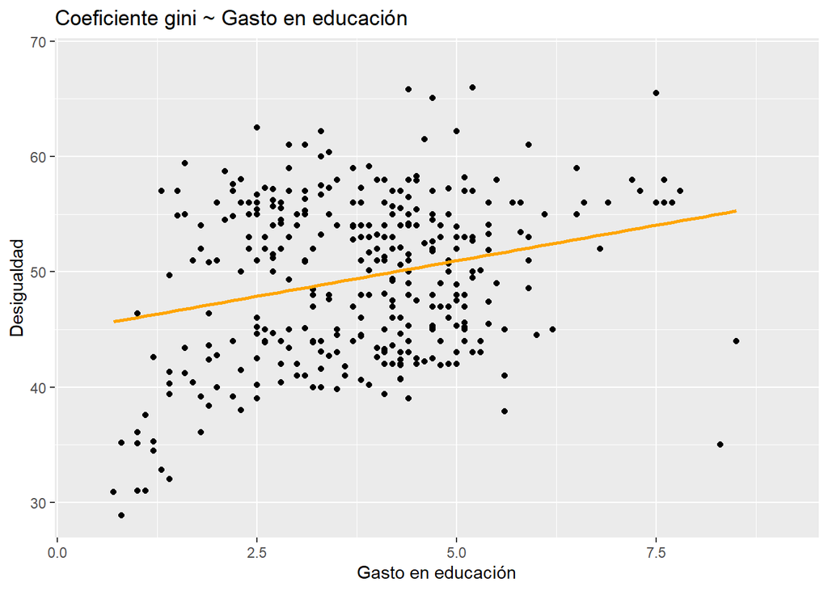

```r
ggplot(data = bienestar, # seleccionamos la base de datos
       aes(x = gasto_educ, y = gini))+ # variables independientes y dependientes
  geom_point(color = "black") + # los valores observados son graficados
  geom_smooth(method = "lm", # La línea de regresión se superpone
              se = F, # el área de error no se grafica con un IC del 95%
              color = "orange")+ # color de la línea
  labs (x = "Gasto en educación", y = "Desigualdad", title = "Coeficiente gini ~ Gasto en educación")
```